# Module 3: Modifying GIS Data in R

IALE 2015 R GIS Workshop

June 8, 2015

# Goal: Learn how to access and modify raster and vector data

## R Packages Needed

```r
library(sp)
library(rgdal)
library(raster)
library(latticeExtra)
```

## Set Your Working Directory

Change this to the correct path name on your machine

```r
setwd("~/Documents/Intro-Spatial-R/module3")
```

This is the syntax for the path on an Apple/Mac for a subfolder in the `Documents` directory. To find out your current working directory in `R` run the command `getwd()` and use `setwd()` to set you working directory. Help for loaded `R` functions can be accessed by running `?function_name` on the command line, e.g. `?setwd`

## Read in Shapefiles

Here we import a polygon boundary of the state of Utah and a set of polygons representing game management units within the state.

```r
utah.wgs84 <- readOGR(dsn = "data", layer = "utah_wgs84") # Utah border, for "pretty" plotting
deer_units <- readOGR(dsn = "data", layer = "deerrange_UT") # Data on deer/elk management units
```

Take a look at the game management data we loaded

```r
summary(deer_units)
```

```
## Object of class SpatialPolygonsDataFrame
## Coordinates:
##          min        max
## x -114.05724 -109.03485
## y   36.99921   42.00169
## Is projected: FALSE
## proj4string :
## [+proj=longlat +datum=WGS84 +no_defs +ellps=WGS84 +towgs84=0,0,0]
## Data attributes:
##    FID_ungula             UName         UNum
##  Min.   : 1.00   South Slope : 4   Min.   : 1.0
##  1st Qu.:15.00   Nine Mile   : 2   1st Qu.: 9.0
##  Median :24.00   North Slope : 2   Median :14.0
##  Mean   :24.14   Wasatch Mtns: 2   Mean   :15.1
##  3rd Qu.:39.00   West Desert : 2   3rd Qu.:20.0
##  Max.   :46.00   Book Cliffs : 1   Max.   :30.0
##                  (Other)     :16
##                       SUName       SUNum       AREA_km2
##  none                    :11   10ab   : 1   Min.   :  589.1
##  Abajo Mountains         : 1   11a    : 1   1st Qu.: 2655.1
##  Anthro                  : 1   11b    : 1   Median : 3968.5
##  Bitter Creek, south     : 1   12     : 1   Mean   : 5873.3
##  Bonanza                 : 1   13a    : 1   3rd Qu.: 6637.8
##  Currant Creek-Avintaquin: 1   14a    : 1   Max.   :23325.1
##  (Other)                 :13   (Other):23
##    SURF_AREA         DEER          DEER_SD            ELK
##  Min.   : 180   Min.   :    0   Min.   :   0.0   Min.   :    0
##  1st Qu.: 998   1st Qu.: 1530   1st Qu.: 171.0   1st Qu.:  109
##  Median :1781   Median : 8300   Median : 524.0   Median : 1020
##  Mean   :2004   Mean   : 7534   Mean   : 704.8   Mean   : 1767
##  3rd Qu.:3161   3rd Qu.:11110   3rd Qu.:1089.0   3rd Qu.: 2210
##  Max.   :4955   Max.   :21180   Max.   :1875.0   Max.   :11180
##
##      ELK_SD          FAWNS          FAWN_SD           CALVES
##  Min.   :  0.0   Min.   : 0.00   Min.   : 0.000   Min.   : 0
##  1st Qu.: 30.0   1st Qu.:54.00   1st Qu.: 5.000   1st Qu.: 0
##  Median : 91.0   Median :61.00   Median : 6.300   Median : 0
##  Mean   :167.4   Mean   :54.52   Mean   : 6.852   Mean   :15
##  3rd Qu.:226.0   3rd Qu.:66.00   3rd Qu.: 9.000   3rd Qu.:42
##  Max.   :968.0   Max.   :79.00   Max.   :14.400   Max.   :56
##
##     CALF_SD         ANNRANGE
##  Min.   :0.000   Min.   :   2.562
##  1st Qu.:0.000   1st Qu.:  41.457
##  Median :0.000   Median : 178.747
##  Mean   :1.783   Mean   : 551.329
##  3rd Qu.:3.000   3rd Qu.: 639.717
##  Max.   :8.600   Max.   :2742.693
##
```

This tells us the characteristics of the object, as well as giving a summary of the attribute data stored in the data table. The attribute data is stored in a slot called `@data` so if we just want to look at the data stored in the object:

```r
summary(deer_units@data)
```

```
##    FID_ungula             UName         UNum
##  Min.   : 1.00   South Slope : 4   Min.   : 1.0
##  1st Qu.:15.00   Nine Mile   : 2   1st Qu.: 9.0
##  Median :24.00   North Slope : 2   Median :14.0
##  Mean   :24.14   Wasatch Mtns: 2   Mean   :15.1
##  3rd Qu.:39.00   West Desert : 2   3rd Qu.:20.0
##  Max.   :46.00   Book Cliffs : 1   Max.   :30.0
##                  (Other)     :16
##                       SUName       SUNum       AREA_km2
##  none                    :11   10ab   : 1   Min.   :  589.1
##  Abajo Mountains         : 1   11a    : 1   1st Qu.: 2655.1
##  Anthro                  : 1   11b    : 1   Median : 3968.5
##  Bitter Creek, south     : 1   12     : 1   Mean   : 5873.3
##  Bonanza                 : 1   13a    : 1   3rd Qu.: 6637.8
##  Currant Creek-Avintaquin: 1   14a    : 1   Max.   :23325.1
##  (Other)                 :13   (Other):23
##    SURF_AREA         DEER          DEER_SD            ELK
##  Min.   : 180   Min.   :    0   Min.   :   0.0   Min.   :    0
##  1st Qu.: 998   1st Qu.: 1530   1st Qu.: 171.0   1st Qu.:  109
##  Median :1781   Median : 8300   Median : 524.0   Median : 1020
##  Mean   :2004   Mean   : 7534   Mean   : 704.8   Mean   : 1767
##  3rd Qu.:3161   3rd Qu.:11110   3rd Qu.:1089.0   3rd Qu.: 2210
##  Max.   :4955   Max.   :21180   Max.   :1875.0   Max.   :11180
##
##      ELK_SD          FAWNS          FAWN_SD           CALVES
##  Min.   :  0.0   Min.   : 0.00   Min.   : 0.000   Min.   : 0
##  1st Qu.: 30.0   1st Qu.:54.00   1st Qu.: 5.000   1st Qu.: 0
##  Median : 91.0   Median :61.00   Median : 6.300   Median : 0
##  Mean   :167.4   Mean   :54.52   Mean   : 6.852   Mean   :15
##  3rd Qu.:226.0   3rd Qu.:66.00   3rd Qu.: 9.000   3rd Qu.:42
##  Max.   :968.0   Max.   :79.00   Max.   :14.400   Max.   :56
##
##     CALF_SD         ANNRANGE
##  Min.   :0.000   Min.   :   2.562
##  1st Qu.:0.000   1st Qu.:  41.457
##  Median :0.000   Median : 178.747
##  Mean   :1.783   Mean   : 551.329
##  3rd Qu.:3.000   3rd Qu.: 639.717
##  Max.   :8.600   Max.   :2742.693
##
```

```r
names(deer_units) # The attribute data names
```

```
##  [1] "FID_ungula" "UName"      "UNum"       "SUName"     "SUNum"
##  [6] "AREA_km2"   "SURF_AREA"  "DEER"       "DEER_SD"    "ELK"
## [11] "ELK_SD"     "FAWNS"      "FAWN_SD"    "CALVES"     "CALF_SD"
## [16] "ANNRANGE"
```

The `@data` slot is in fact a class `data.frame` like would be most other tables loaded into `R`, while the entire object is a Spatial Polygons Data Frame.

```r
class(deer_units)
```

```
## [1] "SpatialPolygonsDataFrame"
## attr(,"package")
## [1] "sp"
```

```r
class(deer_units@data)
```

```
## [1] "data.frame"
```

Make a basic plot with coloring based on `UName`

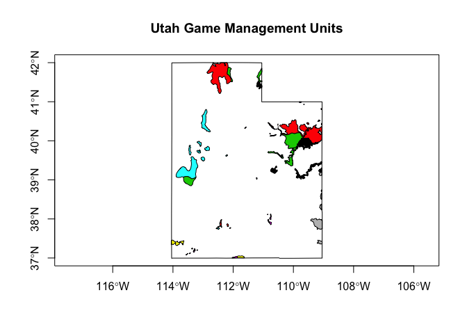

```r
plot(deer_units,
     axes = TRUE, # adds the coordinate ranges to the axes
     col = deer_units$UName, # colors the polygons based on UName
     main = "Utah Game Management Units" # adds main title to plot
     )
plot(utah.wgs84, add = TRUE) # Add the Utah border for reference
```

Use the `spplot` function from `sp` package to provide coloring and a legend based on the `UName` (unit name) attribute of the management units. So, essentially the same plot as above, just a different method.

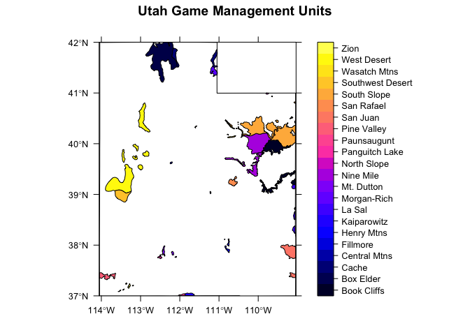

```r
spplot(deer_units, # spatial object (data set) to plot
       c("UName"), # names of columns to plot
       scales = list(draw = TRUE), # this adds the coordinate values to the plot
       main = "Utah Game Management Units" # adds title to map
       # ,sp.layout = list("sp.polygons", utah.wgs84) # adds Utah border to map within call to `spplot` function
       ) +
      layer(sp.polygons(utah.wgs84)) # alternative way to add layers to map; requires `latticeExtra` package, but can be easier to read and follow
```

## Querying data of a vector (shapefile)

Querying the data in a shapefile is much the same as querying any other data frame in `R`. For example, if you want to look at the data only for the West Desert unit:

```r
wd <- deer_units[deer_units$UName == "West Desert",]
summary(wd)
```

```
## Object of class SpatialPolygonsDataFrame
## Coordinates:
##          min        max
## x -113.89531 -112.75650
## y   39.02626   40.80623
## Is projected: FALSE
## proj4string :
## [+proj=longlat +datum=WGS84 +no_defs +ellps=WGS84 +towgs84=0,0,0]
## Data attributes:
##    FID_ungula             UName        UNum                    SUName
##  Min.   :18.00   West Desert :2   Min.   :19   Deep Creeks        :1
##  1st Qu.:19.25   Book Cliffs :0   1st Qu.:19   Vernon             :1
##  Median :20.50   Box Elder   :0   Median :19   Abajo Mountains    :0
##  Mean   :20.50   Cache       :0   Mean   :19   Anthro             :0
##  3rd Qu.:21.75   Central Mtns:0   3rd Qu.:19   Bitter Creek, south:0
##  Max.   :23.00   Fillmore    :0   Max.   :19   Bonanza            :0
##                  (Other)     :0                (Other)            :0
##      SUNum      AREA_km2       SURF_AREA         DEER         DEER_SD
##  19a    :1   Min.   : 3940   Min.   :1223   Min.   :8300   Min.   :524
##  19b    :1   1st Qu.: 7896   1st Qu.:1298   1st Qu.:8300   1st Qu.:524
##  10ab   :0   Median :11851   Median :1373   Median :8300   Median :524
##  11a    :0   Mean   :11851   Mean   :1373   Mean   :8300   Mean   :524
##  11b    :0   3rd Qu.:15807   3rd Qu.:1448   3rd Qu.:8300   3rd Qu.:524
##  12     :0   Max.   :19762   Max.   :1523   Max.   :8300   Max.   :524
##  (Other):0
##       ELK             ELK_SD         FAWNS         FAWN_SD         CALVES
##  Min.   :  0.00   Min.   : 0.0   Min.   :64.0   Min.   : 8.1   Min.   :0
##  1st Qu.: 27.25   1st Qu.:11.5   1st Qu.:65.5   1st Qu.: 9.3   1st Qu.:0
##  Median : 54.50   Median :23.0   Median :67.0   Median :10.5   Median :0
##  Mean   : 54.50   Mean   :23.0   Mean   :67.0   Mean   :10.5   Mean   :0
##  3rd Qu.: 81.75   3rd Qu.:34.5   3rd Qu.:68.5   3rd Qu.:11.7   3rd Qu.:0
##  Max.   :109.00   Max.   :46.0   Max.   :70.0   Max.   :12.9   Max.   :0
##
##     CALF_SD     ANNRANGE
##  Min.   :0   Min.   : 114.8
##  1st Qu.:0   1st Qu.: 771.7
##  Median :0   Median :1428.7
##  Mean   :0   Mean   :1428.7
##  3rd Qu.:0   3rd Qu.:2085.7
##  Max.   :0   Max.   :2742.7
##
```

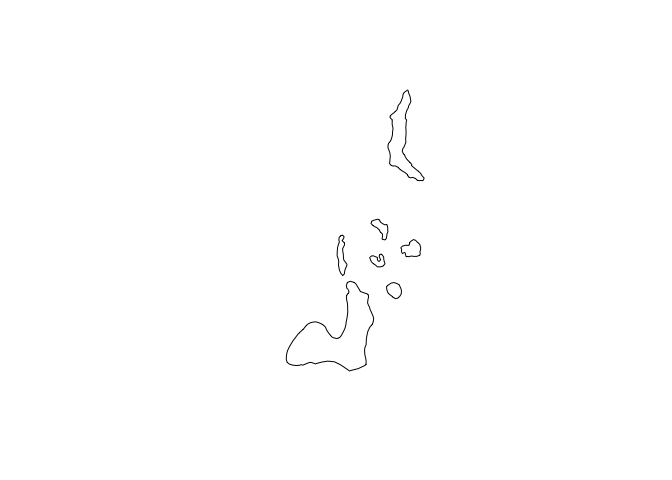

```r
plot(wd)
```

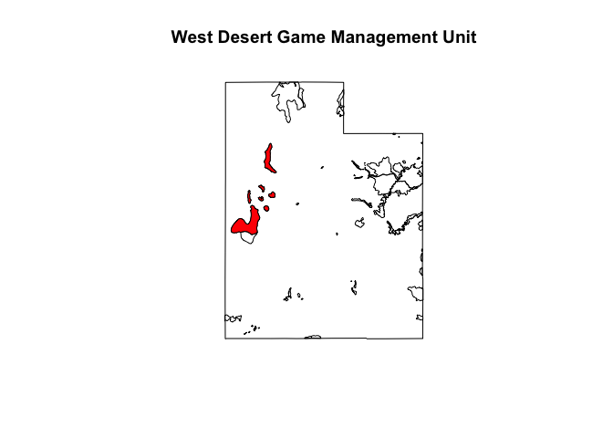

```r
plot(deer_units, main = "West Desert Game Management Unit")
plot(utah.wgs84, add = TRUE)
plot(wd, add = TRUE, col = "red")
```

Or perhaps you just want to have a quick look at how many deer are in the Box Elder unit:

```r
deer_units@data$DEER[deer_units@data$UName == "Box Elder"]
```

```
## [1] 15180
```

Note that these are base `R` methods for indexing. There are also several frequently used packages that have been built to help with manipulation of data as needs become more complex, e.g. `plyr`, `dplyr`, `data.table` are three well known packages.

## Calculate a new field for vector data

Calculating a new field is as easy as adding a new column to any other data frame in `R`. Say we want to calcualte a new field from the existing data, such as the total number of adult deer and elk in each management unit:

```r
# tot_deer_elk is the field we want to add to the deer_units data frame
deer_units$tot_deer_elk <- deer_units$DEER + deer_units$ELK
summary(deer_units@data)
```

```
##    FID_ungula             UName         UNum
##  Min.   : 1.00   South Slope : 4   Min.   : 1.0
##  1st Qu.:15.00   Nine Mile   : 2   1st Qu.: 9.0
##  Median :24.00   North Slope : 2   Median :14.0
##  Mean   :24.14   Wasatch Mtns: 2   Mean   :15.1
##  3rd Qu.:39.00   West Desert : 2   3rd Qu.:20.0
##  Max.   :46.00   Book Cliffs : 1   Max.   :30.0
##                  (Other)     :16
##                       SUName       SUNum       AREA_km2
##  none                    :11   10ab   : 1   Min.   :  589.1
##  Abajo Mountains         : 1   11a    : 1   1st Qu.: 2655.1
##  Anthro                  : 1   11b    : 1   Median : 3968.5
##  Bitter Creek, south     : 1   12     : 1   Mean   : 5873.3
##  Bonanza                 : 1   13a    : 1   3rd Qu.: 6637.8
##  Currant Creek-Avintaquin: 1   14a    : 1   Max.   :23325.1
##  (Other)                 :13   (Other):23
##    SURF_AREA         DEER          DEER_SD            ELK
##  Min.   : 180   Min.   :    0   Min.   :   0.0   Min.   :    0
##  1st Qu.: 998   1st Qu.: 1530   1st Qu.: 171.0   1st Qu.:  109
##  Median :1781   Median : 8300   Median : 524.0   Median : 1020
##  Mean   :2004   Mean   : 7534   Mean   : 704.8   Mean   : 1767
##  3rd Qu.:3161   3rd Qu.:11110   3rd Qu.:1089.0   3rd Qu.: 2210
##  Max.   :4955   Max.   :21180   Max.   :1875.0   Max.   :11180
##
##      ELK_SD          FAWNS          FAWN_SD           CALVES
##  Min.   :  0.0   Min.   : 0.00   Min.   : 0.000   Min.   : 0
##  1st Qu.: 30.0   1st Qu.:54.00   1st Qu.: 5.000   1st Qu.: 0
##  Median : 91.0   Median :61.00   Median : 6.300   Median : 0
##  Mean   :167.4   Mean   :54.52   Mean   : 6.852   Mean   :15
##  3rd Qu.:226.0   3rd Qu.:66.00   3rd Qu.: 9.000   3rd Qu.:42
##  Max.   :968.0   Max.   :79.00   Max.   :14.400   Max.   :56
##
##     CALF_SD         ANNRANGE         tot_deer_elk
##  Min.   :0.000   Min.   :   2.562   Min.   :    0
##  1st Qu.:0.000   1st Qu.:  41.457   1st Qu.: 2604
##  Median :0.000   Median : 178.747   Median : 9786
##  Mean   :1.783   Mean   : 551.329   Mean   : 9302
##  3rd Qu.:3.000   3rd Qu.: 639.717   3rd Qu.:13503
##  Max.   :8.600   Max.   :2742.693   Max.   :32360
##
```

Plot the management units with color based on this new field using the `spplot` function:

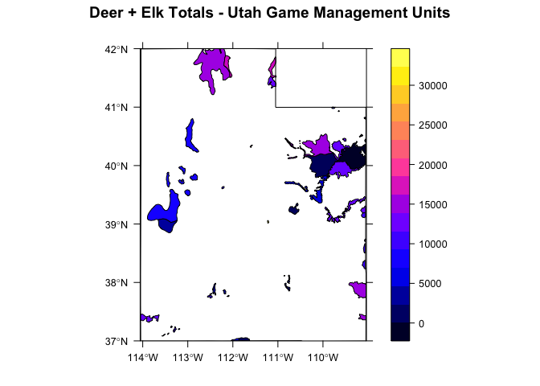

```r
spplot(deer_units, c("tot_deer_elk"), scales = list(draw = TRUE), main = "Deer + Elk Totals - Utah Game Management Units") +
      layer(sp.polygons(utah.wgs84))
```

## Convert vector to raster

Perhaps we want to add some data from a raster, such as a gridded surface of NDVI. NDVI may be indicative of deer and elk population abundance and/or reproductive success. Calculations of NDVI for a given pixel always result in a number that ranges from minus one (-1) to plus one (+1); however, no green leaves gives a value close to zero. A zero means no vegetation and close to +1 (0.8 - 0.9) indicates the highest possible density of green leaves. [More info on NDVI](http://earthobservatory.nasa.gov/Features/MeasuringVegetation/measuring_vegetation_2.php)

First, let’s read in the NDVI raster surface

```r
ndvi500m <- raster("data/N200530602133CBR_v1.1.dat", format = "ENVI")
ndvi500m
```

```
## class       : RasterLayer
## dimensions  : 4288, 4171, 17885248  (nrow, ncol, ncell)
## resolution  : 0.004166667, 0.004166667  (x, y)
## extent      : -121.612, -104.2328, 27.83958, 45.70625  (xmin, xmax, ymin, ymax)
## coord. ref. : +proj=longlat +datum=WGS84 +no_defs +ellps=WGS84 +towgs84=0,0,0
## data source : /Users/wwdillon/Documents/IALE2015_StudentWorkshop/IALE2015_gisRcourse/data/N200530602133CBR_v1.1.dat
## names       : N200530602133CBR_v1.1
## values      : -32768, 32767  (min, max)
```

```r
names(ndvi500m) <- "ndvi" # Change raster attribute name to something meaningful
ndvi500m <- ndvi500m/(ndvi500m@data@max+1)
ndvi500m
```

```
## class       : RasterLayer
## dimensions  : 4288, 4171, 17885248  (nrow, ncol, ncell)
## resolution  : 0.004166667, 0.004166667  (x, y)
## extent      : -121.612, -104.2328, 27.83958, 45.70625  (xmin, xmax, ymin, ymax)
## coord. ref. : +proj=longlat +datum=WGS84 +no_defs +ellps=WGS84 +towgs84=0,0,0
## data source : in memory
## names       : ndvi
## values      : -0.3738403, 0.4416504  (min, max)
```

Note that the projection is in decimal degrees and thus the grain and extent are also given in decimal degrees. Next, check that the projections of our layers are all the same:

```r
all.equal(proj4string(deer_units), proj4string(utah.wgs84), proj4string(ndvi500m))
```

```
## [1] TRUE
```

The `all.equal` function returns `TRUE` if the objects are all the same, and `FALSE` otherwise. So, all of these layers have exactly the same `proj4` string. This is important if we want to draw a map with these surfaces overlain correctly.

Plotting the layers we see that the NDVI surface is much larger than our area of interest, in fact covering much of the southwestern United States.

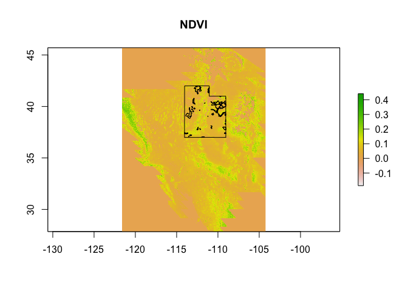

```r
plot(ndvi500m, main = "NDVI")
plot(utah.wgs84, add = TRUE)
plot(deer_units, add = TRUE)
```

So, we can crop the raster to an area that’s a little smaller to make a map of NDVI across the deer ranges in Utah.

```r
ndvi_utah <- crop(ndvi500m, extent(utah.wgs84))
ndvi_utah
```

```
## class       : RasterLayer
## dimensions  : 1202, 1200, 1442400  (nrow, ncol, ncell)
## resolution  : 0.004166667, 0.004166667  (x, y)
## extent      : -114.0453, -109.0453, 36.99375, 42.00208  (xmin, xmax, ymin, ymax)
## coord. ref. : +proj=longlat +datum=WGS84 +no_defs +ellps=WGS84 +towgs84=0,0,0
## data source : in memory
## names       : ndvi
## values      : -0.01159668, 0.239624  (min, max)
```

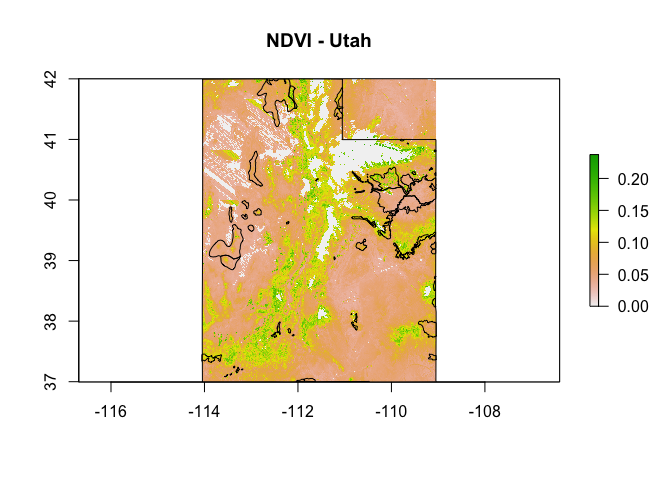

```r
plot(ndvi_utah, main = "NDVI - Utah")
plot(utah.wgs84, add = TRUE)
plot(deer_units, add = TRUE)
```

Now we can create a new raster of using the management units based on the NDVI raster’s grain and extent that was cropped for Utah. This is used to demonstrate masking the data from a raster with a larger extent.

```r
system.time(deer_units.rast <- rasterize(deer_units, ndvi_utah, deer_units$UNum)) # note this took about 5 seconds on my 16 GB RAM laptop
```

```
##    user  system elapsed
##   5.580   0.033   5.651
```

```r
deer_units.rast
```

```
## class       : RasterLayer
## dimensions  : 1202, 1200, 1442400  (nrow, ncol, ncell)
## resolution  : 0.004166667, 0.004166667  (x, y)
## extent      : -114.0453, -109.0453, 36.99375, 42.00208  (xmin, xmax, ymin, ymax)
## coord. ref. : +proj=longlat +datum=WGS84 +no_defs +ellps=WGS84 +towgs84=0,0,0
## data source : in memory
## names       : layer
## values      : 1, 30  (min, max)
```

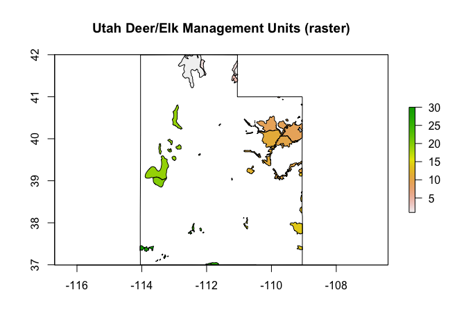

```r
names(deer_units.rast) <- "UNum" # Rename this to the correct value

## Examine plots; colors correspond to the value of UNum
plot(deer_units.rast, main = "Utah Deer/Elk Management Units (raster)") # note that this retains the extent of the input raster
plot(deer_units, add = TRUE)
plot(utah.wgs84 , add = TRUE)
```

Not demonstrated here is the method to convert rasters to polygons. This can be accomplished using the `rasterToPolygons` function from the `raster` package.

## Subsetting/masking data

We can use the deer range raster, which matches (and must match) the extent, grain, and projection of the cropped NDVI data, to mask NDVI raster based on the management units. Masking can be done using either another raster or spatial object (e.g. polygons)

```r
# First using the raster we created
ndvi_deer.mask1 <- mask(ndvi_utah, deer_units.rast)
# Second using the original spatial polygons
ndvi_deer.mask2 <- mask(ndvi_utah, deer_units)
# Compare the results of the two masking methods
ndvi_deer.mask1
```

```
## class       : RasterLayer
## dimensions  : 1202, 1200, 1442400  (nrow, ncol, ncell)
## resolution  : 0.004166667, 0.004166667  (x, y)
## extent      : -114.0453, -109.0453, 36.99375, 42.00208  (xmin, xmax, ymin, ymax)
## coord. ref. : +proj=longlat +datum=WGS84 +no_defs +ellps=WGS84 +towgs84=0,0,0
## data source : in memory
## names       : ndvi
## values      : 0, 0.239624  (min, max)
```

```r
ndvi_deer.mask2
```

```
## class       : RasterLayer
## dimensions  : 1202, 1200, 1442400  (nrow, ncol, ncell)
## resolution  : 0.004166667, 0.004166667  (x, y)
## extent      : -114.0453, -109.0453, 36.99375, 42.00208  (xmin, xmax, ymin, ymax)
## coord. ref. : +proj=longlat +datum=WGS84 +no_defs +ellps=WGS84 +towgs84=0,0,0
## data source : in memory
## names       : ndvi
## values      : 0, 0.239624  (min, max)
```

```r
all.equal(ndvi_deer.mask1, ndvi_deer.mask2)
```

```
## [1] TRUE
```

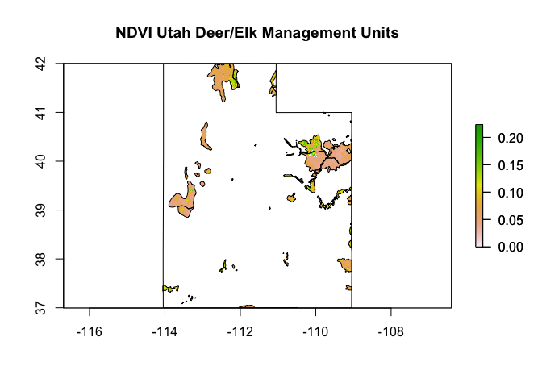

```r
plot(ndvi_deer.mask1, main = "NDVI Utah Deer/Elk Management Units")
plot(ndvi_deer.mask2, add = TRUE) # note nothing changes, exactly the same plot
plot(utah.wgs84, add = TRUE)
plot(deer_units, add = TRUE)
```

To generate this masked raster we didn’t need to convert the polygons to a raster, but this demonstrates the capabilities of processing from whichever data type you begin with.

Now we’ll calculate the mean NDVI for each deer/elk management unit and add it to the data frame - a hint of whats to come in the next module. Here we add the column `avg.ndvi1` to the `deer_units` data frame by extracting it from the `ndvi_utah`.

```r
deer_units$avg.ndvi <- extract(
      ndvi_utah, # the raster to extract values frome
      deer_units, # the point/line/polygon defining the locations to extract/summarise values for
      fun = mean, na.rm=T # the function to apply to the cells in those zones
      )
summary(deer_units)
```

```
## Object of class SpatialPolygonsDataFrame
## Coordinates:
##          min        max
## x -114.05724 -109.03485
## y   36.99921   42.00169
## Is projected: FALSE
## proj4string :
## [+proj=longlat +datum=WGS84 +no_defs +ellps=WGS84 +towgs84=0,0,0]
## Data attributes:
##    FID_ungula             UName         UNum
##  Min.   : 1.00   South Slope : 4   Min.   : 1.0
##  1st Qu.:15.00   Nine Mile   : 2   1st Qu.: 9.0
##  Median :24.00   North Slope : 2   Median :14.0
##  Mean   :24.14   Wasatch Mtns: 2   Mean   :15.1
##  3rd Qu.:39.00   West Desert : 2   3rd Qu.:20.0
##  Max.   :46.00   Book Cliffs : 1   Max.   :30.0
##                  (Other)     :16
##                       SUName       SUNum       AREA_km2
##  none                    :11   10ab   : 1   Min.   :  589.1
##  Abajo Mountains         : 1   11a    : 1   1st Qu.: 2655.1
##  Anthro                  : 1   11b    : 1   Median : 3968.5
##  Bitter Creek, south     : 1   12     : 1   Mean   : 5873.3
##  Bonanza                 : 1   13a    : 1   3rd Qu.: 6637.8
##  Currant Creek-Avintaquin: 1   14a    : 1   Max.   :23325.1
##  (Other)                 :13   (Other):23
##    SURF_AREA         DEER          DEER_SD            ELK
##  Min.   : 180   Min.   :    0   Min.   :   0.0   Min.   :    0
##  1st Qu.: 998   1st Qu.: 1530   1st Qu.: 171.0   1st Qu.:  109
##  Median :1781   Median : 8300   Median : 524.0   Median : 1020
##  Mean   :2004   Mean   : 7534   Mean   : 704.8   Mean   : 1767
##  3rd Qu.:3161   3rd Qu.:11110   3rd Qu.:1089.0   3rd Qu.: 2210
##  Max.   :4955   Max.   :21180   Max.   :1875.0   Max.   :11180
##
##      ELK_SD          FAWNS          FAWN_SD           CALVES
##  Min.   :  0.0   Min.   : 0.00   Min.   : 0.000   Min.   : 0
##  1st Qu.: 30.0   1st Qu.:54.00   1st Qu.: 5.000   1st Qu.: 0
##  Median : 91.0   Median :61.00   Median : 6.300   Median : 0
##  Mean   :167.4   Mean   :54.52   Mean   : 6.852   Mean   :15
##  3rd Qu.:226.0   3rd Qu.:66.00   3rd Qu.: 9.000   3rd Qu.:42
##  Max.   :968.0   Max.   :79.00   Max.   :14.400   Max.   :56
##
##     CALF_SD         ANNRANGE         tot_deer_elk       avg.ndvi.V1
##  Min.   :0.000   Min.   :   2.562   Min.   :    0   Min.   :0.03013252
##  1st Qu.:0.000   1st Qu.:  41.457   1st Qu.: 2604   1st Qu.:0.05887772
##  Median :0.000   Median : 178.747   Median : 9786   Median :0.07166978
##  Mean   :1.783   Mean   : 551.329   Mean   : 9302   Mean   :0.07733062
##  3rd Qu.:3.000   3rd Qu.: 639.717   3rd Qu.:13503   3rd Qu.:0.09622171
##  Max.   :8.600   Max.   :2742.693   Max.   :32360   Max.   :0.12515570
##
```

```r
names(deer_units)
```

```
##  [1] "FID_ungula"   "UName"        "UNum"         "SUName"
##  [5] "SUNum"        "AREA_km2"     "SURF_AREA"    "DEER"
##  [9] "DEER_SD"      "ELK"          "ELK_SD"       "FAWNS"
## [13] "FAWN_SD"      "CALVES"       "CALF_SD"      "ANNRANGE"
## [17] "tot_deer_elk" "avg.ndvi"
```

Notice in the summary that we get a bit of a funny looking result from the `extract` function. An investigation of the class of that variable reveals that the result is a matrix, even though it is only a single column. This normal behavior for `SpatialPolygons*` or `SpatialLines*` objects. We just want a numeric vector in our data frame, which is accomplished with a call to `as.vector`. If this was not changed to a vector then it would cause errors when trying to export the object as a new shapefile (learned from this experience).

```r
class(deer_units$avg.ndvi)
```

```
## [1] "matrix"
```

```r
deer_units$avg.ndvi <- as.vector(deer_units$avg.ndvi)
```

Now let’s make a map of the averaged NDVI for each of the deer and elk management units across Utah

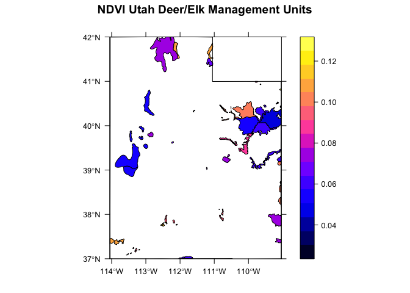

```r
spplot(deer_units, c("avg.ndvi"), scales = list(draw = TRUE), main = "NDVI Utah Deer/Elk Management Units") +
      layer(sp.polygons(utah.wgs84))
```

## Adding attributes by joining data

The deer/elk management units are smaller areas within larger game management units in Utah.

```r
mgt_units <- readOGR(dsn = "data", layer = "deerunits_UT")
```

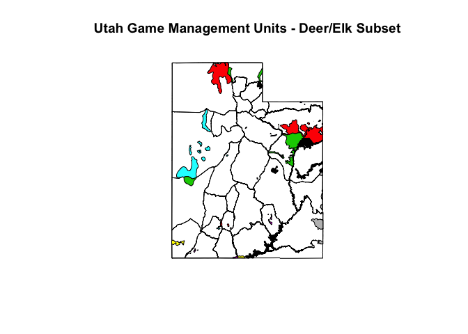

```r
plot(mgt_units, main = "Utah Game Management Units - Deer/Elk Subset")
plot(utah.wgs84, add = TRUE)
plot(deer_units, add = TRUE, col = deer_units$UName)
```

So we might be interested in joining the data from one to the other, such as some of data about the larger units to the specific deer/elk data.

```r
summary(mgt_units)
```

```
## Object of class SpatialPolygonsDataFrame
## Coordinates:
##          min        max
## x -114.05417 -109.04093
## y   36.99921   42.00195
## Is projected: FALSE
## proj4string :
## [+proj=longlat +datum=WGS84 +no_defs +ellps=WGS84 +towgs84=0,0,0]
## Data attributes:
##     UNIT_NUM     SU_LETTER             UNIT_NAME              SU_NAME
##  Min.   : 1.00   A:20      Beaver           : 1   none            :16
##  1st Qu.: 8.25   B: 5      Book Cliffs      : 1   Avintaquin      : 1
##  Median :15.50   C: 4      Box Elder        : 1   Bonanza         : 1
##  Mean   :15.50   D: 1      Cache            : 1   Boulder         : 1
##  3rd Qu.:22.75             Central Mountains: 1   Cache           : 1
##  Max.   :30.00             Chalk Creek      : 1   Dolores Triangle: 1
##                            (Other)          :24   (Other)         : 9
##    UNIT_CODE        Unit_sub       Area               Acres
##  Min.   : 3.00   10C    : 1   Min.   :3.636e+11   Min.   :  57970
##  1st Qu.:11.75   11B    : 1   1st Qu.:2.590e+12   1st Qu.: 412963
##  Median :23.50   12A    : 1   Median :4.541e+12   Median : 723893
##  Mean   :24.87   13B    : 1   Mean   :6.384e+12   Mean   :1017683
##  3rd Qu.:34.50   14B    : 1   3rd Qu.:7.966e+12   3rd Qu.:1269930
##  Max.   :61.00   15     : 1   Max.   :2.091e+13   Max.   :3333330
##                  (Other):24
##     Hectares          Dissolve
##  Min.   :  23460   Min.   :  1.00
##  1st Qu.: 167120   1st Qu.:  8.75
##  Median : 292949   Median : 26.00
##  Mean   : 411842   Mean   : 66.27
##  3rd Qu.: 513922   3rd Qu.: 99.00
##  Max.   :1348951   Max.   :252.00
##
```

```r
summary(deer_units)
```

```
## Object of class SpatialPolygonsDataFrame
## Coordinates:
##          min        max
## x -114.05724 -109.03485
## y   36.99921   42.00169
## Is projected: FALSE
## proj4string :
## [+proj=longlat +datum=WGS84 +no_defs +ellps=WGS84 +towgs84=0,0,0]
## Data attributes:
##    FID_ungula             UName         UNum
##  Min.   : 1.00   South Slope : 4   Min.   : 1.0
##  1st Qu.:15.00   Nine Mile   : 2   1st Qu.: 9.0
##  Median :24.00   North Slope : 2   Median :14.0
##  Mean   :24.14   Wasatch Mtns: 2   Mean   :15.1
##  3rd Qu.:39.00   West Desert : 2   3rd Qu.:20.0
##  Max.   :46.00   Book Cliffs : 1   Max.   :30.0
##                  (Other)     :16
##                       SUName       SUNum       AREA_km2
##  none                    :11   10ab   : 1   Min.   :  589.1
##  Abajo Mountains         : 1   11a    : 1   1st Qu.: 2655.1
##  Anthro                  : 1   11b    : 1   Median : 3968.5
##  Bitter Creek, south     : 1   12     : 1   Mean   : 5873.3
##  Bonanza                 : 1   13a    : 1   3rd Qu.: 6637.8
##  Currant Creek-Avintaquin: 1   14a    : 1   Max.   :23325.1
##  (Other)                 :13   (Other):23
##    SURF_AREA         DEER          DEER_SD            ELK
##  Min.   : 180   Min.   :    0   Min.   :   0.0   Min.   :    0
##  1st Qu.: 998   1st Qu.: 1530   1st Qu.: 171.0   1st Qu.:  109
##  Median :1781   Median : 8300   Median : 524.0   Median : 1020
##  Mean   :2004   Mean   : 7534   Mean   : 704.8   Mean   : 1767
##  3rd Qu.:3161   3rd Qu.:11110   3rd Qu.:1089.0   3rd Qu.: 2210
##  Max.   :4955   Max.   :21180   Max.   :1875.0   Max.   :11180
##
##      ELK_SD          FAWNS          FAWN_SD           CALVES
##  Min.   :  0.0   Min.   : 0.00   Min.   : 0.000   Min.   : 0
##  1st Qu.: 30.0   1st Qu.:54.00   1st Qu.: 5.000   1st Qu.: 0
##  Median : 91.0   Median :61.00   Median : 6.300   Median : 0
##  Mean   :167.4   Mean   :54.52   Mean   : 6.852   Mean   :15
##  3rd Qu.:226.0   3rd Qu.:66.00   3rd Qu.: 9.000   3rd Qu.:42
##  Max.   :968.0   Max.   :79.00   Max.   :14.400   Max.   :56
##
##     CALF_SD         ANNRANGE         tot_deer_elk      avg.ndvi
##  Min.   :0.000   Min.   :   2.562   Min.   :    0   Min.   :0.03013
##  1st Qu.:0.000   1st Qu.:  41.457   1st Qu.: 2604   1st Qu.:0.05888
##  Median :0.000   Median : 178.747   Median : 9786   Median :0.07167
##  Mean   :1.783   Mean   : 551.329   Mean   : 9302   Mean   :0.07733
##  3rd Qu.:3.000   3rd Qu.: 639.717   3rd Qu.:13503   3rd Qu.:0.09622
##  Max.   :8.600   Max.   :2742.693   Max.   :32360   Max.   :0.12516
##
```

```r
names(mgt_units)
```

```
##  [1] "UNIT_NUM"  "SU_LETTER" "UNIT_NAME" "SU_NAME"   "UNIT_CODE"
##  [6] "Unit_sub"  "Area"      "Acres"     "Hectares"  "Dissolve"
```

```r
names(deer_units)
```

```
##  [1] "FID_ungula"   "UName"        "UNum"         "SUName"
##  [5] "SUNum"        "AREA_km2"     "SURF_AREA"    "DEER"
##  [9] "DEER_SD"      "ELK"          "ELK_SD"       "FAWNS"
## [13] "FAWN_SD"      "CALVES"       "CALF_SD"      "ANNRANGE"
## [17] "tot_deer_elk" "avg.ndvi"
```

Notice that the colun names don’t match up precisely, so we will rename the column that we wan’t to base the join on in one of the data frames to match the other. This can also be done by column number index, but a common column name makes things much clearer.

```r
names(mgt_units@data)[names(mgt_units@data) == "UNIT_NUM"] <- "UNum"
deer_units@data <- merge(deer_units@data, # data frame to join more data to
                         mgt_units@data, # data frame to join data from
                         by = "UNum", # the column name to base the merge on; this can also be the column name if it is the same for both data frames
                         all.x = TRUE # adds extra rows with NAs when there are no matches in second object; in other words, retains all of deer_units data
                         )
summary(deer_units@data)
```

```
##       UNum        FID_ungula             UName
##  Min.   : 1.0   Min.   : 1.00   South Slope : 4
##  1st Qu.: 9.0   1st Qu.:15.00   Nine Mile   : 2
##  Median :14.0   Median :24.00   North Slope : 2
##  Mean   :15.1   Mean   :24.14   Wasatch Mtns: 2
##  3rd Qu.:20.0   3rd Qu.:39.00   West Desert : 2
##  Max.   :30.0   Max.   :46.00   Book Cliffs : 1
##                                 (Other)     :16
##                       SUName       SUNum       AREA_km2
##  none                    :11   10ab   : 1   Min.   :  589.1
##  Abajo Mountains         : 1   11a    : 1   1st Qu.: 2655.1
##  Anthro                  : 1   11b    : 1   Median : 3968.5
##  Bitter Creek, south     : 1   12     : 1   Mean   : 5873.3
##  Bonanza                 : 1   13a    : 1   3rd Qu.: 6637.8
##  Currant Creek-Avintaquin: 1   14a    : 1   Max.   :23325.1
##  (Other)                 :13   (Other):23
##    SURF_AREA         DEER          DEER_SD            ELK
##  Min.   : 180   Min.   :    0   Min.   :   0.0   Min.   :    0
##  1st Qu.: 998   1st Qu.: 1530   1st Qu.: 171.0   1st Qu.:  109
##  Median :1781   Median : 8300   Median : 524.0   Median : 1020
##  Mean   :2004   Mean   : 7534   Mean   : 704.8   Mean   : 1767
##  3rd Qu.:3161   3rd Qu.:11110   3rd Qu.:1089.0   3rd Qu.: 2210
##  Max.   :4955   Max.   :21180   Max.   :1875.0   Max.   :11180
##
##      ELK_SD          FAWNS          FAWN_SD           CALVES
##  Min.   :  0.0   Min.   : 0.00   Min.   : 0.000   Min.   : 0
##  1st Qu.: 30.0   1st Qu.:54.00   1st Qu.: 5.000   1st Qu.: 0
##  Median : 91.0   Median :61.00   Median : 6.300   Median : 0
##  Mean   :167.4   Mean   :54.52   Mean   : 6.852   Mean   :15
##  3rd Qu.:226.0   3rd Qu.:66.00   3rd Qu.: 9.000   3rd Qu.:42
##  Max.   :968.0   Max.   :79.00   Max.   :14.400   Max.   :56
##
##     CALF_SD         ANNRANGE         tot_deer_elk      avg.ndvi
##  Min.   :0.000   Min.   :   2.562   Min.   :    0   Min.   :0.03013
##  1st Qu.:0.000   1st Qu.:  41.457   1st Qu.: 2604   1st Qu.:0.05888
##  Median :0.000   Median : 178.747   Median : 9786   Median :0.07167
##  Mean   :1.783   Mean   : 551.329   Mean   : 9302   Mean   :0.07733
##  3rd Qu.:3.000   3rd Qu.: 639.717   3rd Qu.:13503   3rd Qu.:0.09622
##  Max.   :8.600   Max.   :2742.693   Max.   :32360   Max.   :0.12516
##
```

[output cut: 9 more lines]

```
##  9D     : 4   Min.   :3.636e+11   Min.   :  57970   Min.   :  23460
##  11B    : 2   1st Qu.:3.257e+12   1st Qu.: 519237   1st Qu.: 210128
##  17C    : 2   Median :5.381e+12   Median : 857905   Median : 347182
##  19B    : 2   Mean   :6.430e+12   Mean   :1025057   Mean   : 414826
##  8B     : 2   3rd Qu.:6.904e+12   3rd Qu.:1100669   3rd Qu.: 445425
##  10C    : 1   Max.   :2.091e+13   Max.   :3333330   Max.   :1348951
##  (Other):16
##     Dissolve
##  Min.   :  1.00
##  1st Qu.: 12.00
##  Median : 92.00
##  Mean   : 76.48
##  3rd Qu.: 99.00
##  Max.   :252.00
##
```

## Write out spatial polygons shapefiles

We will export the `deer_units` object as a new shapefile to the `outdata` subfolder.

```r
writeOGR(deer_units, # the object we want to save
         dsn = "data/outdata", # the path to the folder we want to save it in
         layer = "deerrange_UT2", # the name we want to give the layer
         driver = "ESRI Shapefile", # the drive provides the proper extension
         overwrite_layer = TRUE # this enables overwriting an existing file with the same name
         )
```